# Students performance

Elena Spirova

2023-06-08

# 1. Introduction

Student results on exams are a reflection of their hard work, dedication, and the knowledge they have acquired. Exams provide an opportunity for students to demonstrate their understanding of the subject matter, apply critical thinking skills, and showcase their academic achievements.

Exam results can vary from student to student, as each individual possesses unique strengths, learning styles, and levels of preparation. Some students may excel and achieve high scores, indicating a deep understanding of the material and mastery of the concepts. On the other hand, some students may face challenges and receive lower scores.

With this project our aim will be to find out what are the patterns of successful and unsuccessful students and what they depend on.

We will use the *“Student Performance in exams dataset”* provided from keegle for this study.

# 2. Presentation and Description of the Problem

## Student Performance In Exams

This data set consists of the marks secured by the students in various subjects. All of the information in this dataset is fictional.

We would like to see how the variables from our data set correlate with one another. For example, we will show how *parental level of education* correlates with the performance of the students in exams, by seeing how it effects the performance of students in their math, reading and writing exam . The most important correlation we will look for is how the 5 independent variables correlate with performance of students on the average *grades* of the three different exams - the dependent variable of the data set. We will also see the gender distribution of the exam results.

At the end we will try to draw a conclusion and see which independent variables have the most effect.

Our next step will be loading the data.

```r
csv_dir <- paste0(getwd(), "/archive")
data <- read.csv(paste0(csv_dir, "/StudentsPerformance.csv"))
```

# 3. Presentation of the Data

## The Dataset:

```r
datatable(data, rownames = F, filter = "top", caption = "Student Performance on Exams", options = list(searching = F, pageLength = 5, lengthMenu = c(5, 10), scrollX = T,  autoWidth = T))
```

| gender | race.ethnicity | parental.level.of.education | lunch | test.preparation.course | math.score | reading.score | writing.score |
| --- | --- | --- | --- | --- | --- | --- | --- |
| female | group B | bachelor's degree | standard | none | 72 | 72 | 74 |
| female | group C | some college | standard | completed | 69 | 90 | 88 |
| female | group B | master's degree | standard | none | 90 | 95 | 93 |
| male | group A | associate's degree | free/reduced | none | 47 | 57 | 44 |
| male | group C | some college | standard | none | 76 | 78 | 75 |
| female | group B | associate's degree | standard | none | 71 | 83 | 78 |
| female | group B | some college | standard | completed | 88 | 95 | 92 |
| male | group B | some college | free/reduced | none | 40 | 43 | 39 |
| male | group D | high school | free/reduced | completed | 64 | 64 | 67 |
| female | group B | high school | free/reduced | none | 38 | 60 | 50 |

[output cut: 990 more lines]

## Content Description

The data contains 8 columns and 1000 rows (entries of data).

```r
print(colnames(data))
```

```
## [1] "gender"                      "race.ethnicity"
## [3] "parental.level.of.education" "lunch"
## [5] "test.preparation.course"     "math.score"
## [7] "reading.score"               "writing.score"
```

```r
print(paste("Entires number:", dim(data)[1]))
```

```
## [1] "Entires number: 1000"
```

### Meaning of the variables:

- Gender : The gender of the student, two values possible (male/female)
- Race ethnicity : These will just be denoted as group A, B, C, D, E.
- Parental level of education : the there are 6 options
  - Bachelor’s degree
  - Some college
  - Master’s degree
  - Associate’s degree
  - High school
  - Some high school
- Lunch : contains information as to whether the lunch of the student was free/reduced price, or he/she had to pay standard for it.
- Test preparation course : contains values as to whether the student completed the preparation course or did not attend one.
- Math score : how many points the student has obtained on his/hers math exam (0-100)
- Reading score : how many points the student has obtained on his/hers reading exam (0-100)
- Writing score : how many points the student has obtained on his/hers writing exam (0-100)

## Overview of the Data

### Data-type Info

Using the `str()` to display the internal structure of the data set.

```r
str(data)
```

```
## 'data.frame':    1000 obs. of  8 variables:
##  $ gender                     : chr  "female" "female" "female" "male" ...
##  $ race.ethnicity             : chr  "group B" "group C" "group B" "group A" ...
##  $ parental.level.of.education: chr  "bachelor's degree" "some college" "master's degree" "associate's degree" ...
##  $ lunch                      : chr  "standard" "standard" "standard" "free/reduced" ...
##  $ test.preparation.course    : chr  "none" "completed" "none" "none" ...
##  $ math.score                 : int  72 69 90 47 76 71 88 40 64 38 ...
##  $ reading.score              : int  72 90 95 57 78 83 95 43 64 60 ...
##  $ writing.score              : int  74 88 93 44 75 78 92 39 67 50 ...
```

### Summarization

Using the `summary()` function we do statistical analysis on our data.

```r
summary(data)
```

```
##     gender          race.ethnicity     parental.level.of.education
##  Length:1000        Length:1000        Length:1000
##  Class :character   Class :character   Class :character
##  Mode  :character   Mode  :character   Mode  :character
##
##
##
##     lunch           test.preparation.course   math.score     reading.score
##  Length:1000        Length:1000             Min.   :  0.00   Min.   : 17.00
##  Class :character   Class :character        1st Qu.: 57.00   1st Qu.: 59.00
##  Mode  :character   Mode  :character        Median : 66.00   Median : 70.00
##                                             Mean   : 66.09   Mean   : 69.17
##                                             3rd Qu.: 77.00   3rd Qu.: 79.00
##                                             Max.   :100.00   Max.   :100.00
##  writing.score
##  Min.   : 10.00
##  1st Qu.: 57.75
##  Median : 69.00
##  Mean   : 68.05
##  3rd Qu.: 79.00
##  Max.   :100.00
```

#### Observation of the summary

```r
summarizeColumns(data) %>%
  datatable(.,
            class = "stripe hover row-border order-column",
            options = list(pageLength = 12,
                           scrollX = T),
            autoHideNavigation = T)
```

|  | name | type | na | mean | disp | median | mad | min | max | nlevs |
| --- | --- | --- | --- | --- | --- | --- | --- | --- | --- | --- |
| 1 | gender | character | 0 |  | 0.482 |  |  | 482 | 518 | 2 |
| 2 | race.ethnicity | character | 0 |  | 0.681 |  |  | 89 | 319 | 5 |
| 3 | parental.level.of.education | character | 0 |  | 0.774 |  |  | 59 | 226 | 6 |
| 4 | lunch | character | 0 |  | 0.355 |  |  | 355 | 645 | 2 |
| 5 | test.preparation.course | character | 0 |  | 0.358 |  |  | 358 | 642 | 2 |
| 6 | math.score | integer | 0 | 66.089 | 15.1630800960095 | 66 | 14.826 | 0 | 100 | 0 |
| 7 | reading.score | integer | 0 | 69.169 | 14.6001919372522 | 70 | 14.826 | 17 | 100 | 0 |
| 8 | writing.score | integer | 0 | 68.054 | 15.1956570108697 | 69 | 16.3086 | 10 | 100 | 0 |

From observing this we can conclude that the students did the worst on their math exam since their average grades for it are the smallest and the minimum value is also the smallest.

We can also say that the best results were on their reading exam. Not much can be said about other values since they are not numeric.

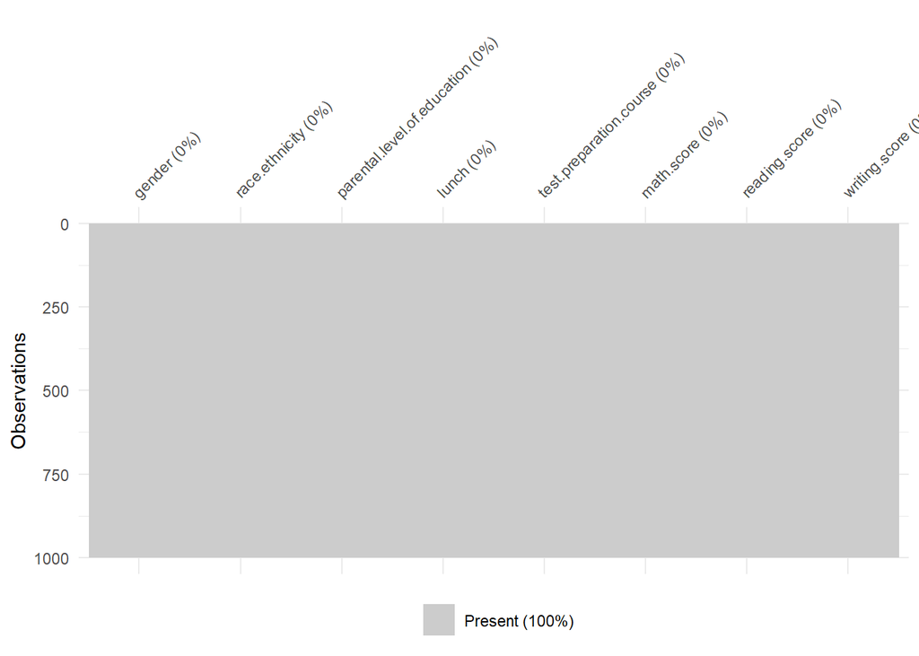

```r
vis_miss(data)
```

```r
sum(is.na(data))
```

```
## [1] 0
```

As we can see we have no missing values and therefore there is no visualization of their patterns.

# 4. Data preparation

For the sake of our research we will create and add three new columns.

1. First of all let’s set the passmark for every exam to be 50.

```r
 passmark = 50
```

2. Now let’s add columns named “Percentage”, “Grade” and “Qualification” :

```r
data <- data %>% mutate( Percentage = c ( Percentage = ( .$math.score + .$writing.score + .$reading.score ) / 3))

data <- data %>% mutate( Grade = c (Grade = case_when(
  Percentage == 100 ~ "O",
  Percentage >= 90 ~ "A",
  Percentage >= 80 ~ "B",
  Percentage >= 70 ~ "C",
  Percentage >= 60 ~ "D",
  Percentage >= 50 ~ "E",
  TRUE ~ "F"

)))


data <- data %>% mutate(Qualification = c (Qualification = case_when(
  Grade == "O" ~ "Outstanding",
  Grade == "A" ~ "Excellent",
  Grade == "B" ~ "Very Good",
  Grade == "C" ~ "Good",
  Grade == "D" ~ "Sufficient",
  Grade == "E" ~ "Pass",
  TRUE ~ "Fail"

)))


 datatable(data,
            class = "stripe hover row-border order-column",
            options = list(pageLength = 12,
                           scrollX = T),
            autoHideNavigation = T)
```

|  | gender | race.ethnicity | parental.level.of.education | lunch | test.preparation.course | math.score | reading.score | writing.score | Percentage | Grade | Qualification |
| --- | --- | --- | --- | --- | --- | --- | --- | --- | --- | --- | --- |
| 1 | female | group B | bachelor's degree | standard | none | 72 | 72 | 74 | 72.6666666666667 | C | Good |
| 2 | female | group C | some college | standard | completed | 69 | 90 | 88 | 82.3333333333333 | B | Very Good |
| 3 | female | group B | master's degree | standard | none | 90 | 95 | 93 | 92.6666666666667 | A | Excellent |
| 4 | male | group A | associate's degree | free/reduced | none | 47 | 57 | 44 | 49.3333333333333 | F | Fail |
| 5 | male | group C | some college | standard | none | 76 | 78 | 75 | 76.3333333333333 | C | Good |
| 6 | female | group B | associate's degree | standard | none | 71 | 83 | 78 | 77.3333333333333 | C | Good |
| 7 | female | group B | some college | standard | completed | 88 | 95 | 92 | 91.6666666666667 | A | Excellent |
| 8 | male | group B | some college | free/reduced | none | 40 | 43 | 39 | 40.6666666666667 | F | Fail |
| 9 | male | group D | high school | free/reduced | completed | 64 | 64 | 67 | 65 | D | Sufficient |
| 10 | female | group B | high school | free/reduced | none | 38 | 60 | 50 | 49.3333333333333 | F | Fail |

[output cut: 990 more lines]

# 5. Exploratory Data Analysis and Visulisation

Now we will start visualizing our data:

## Number of boys vs. number of girls

1. We will find out the percentage of male and female students taking the exam.

[figure not shown]

```r
data %>%
  ggplot(aes( x = gender ))+
  geom_bar(fill = "steelblue", color = "black")+
  labs(x = "Gender", y = "Count", title = "Distribution of gender") +
  scale_y_continuous(labels = scales::percent_format())
```

```r
percentage_diff<-data %>% summarize(girls_percentage = sum(gender == "female") / n()) %>%
  mutate( boys_percentage = 1 - girls_percentage )%>%
  mutate( diff_percentage = girls_percentage - boys_percentage )
gender_diff<-percentage_diff$diff_percentage*100
```

So, now we can see that there are more girls in this dataset and that they beat boys in number by 3.6 % .

## Gender vs. Grades

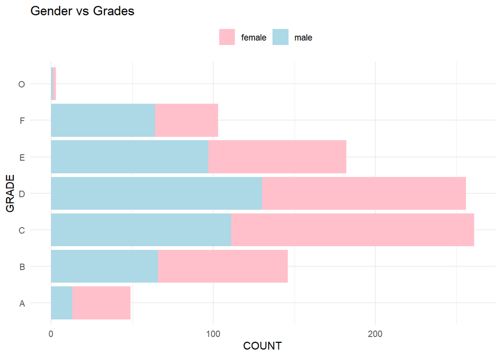

```r
options(repr.plot.width = 10, repr.plot.height =5)

theme_set(theme_minimal())
colors <- c("male" = "lightblue", "female" = "pink")

ggplot(data, aes(x = Grade, fill = gender, order = Grade))+
  geom_bar()+
  labs(x = "GRADE", y = "COUNT", title = "Gender vs Grades") +
  scale_fill_manual(values = colors) +
  theme(legend.position = "top", legend.title = element_blank()) +
  guides(fill = guide_legend(title = "Gender")) +
  coord_flip()
```

With this we can confirm that gender is in fact a factor in whether pupils are successful in exams.

## Observing the scores for each of the exams

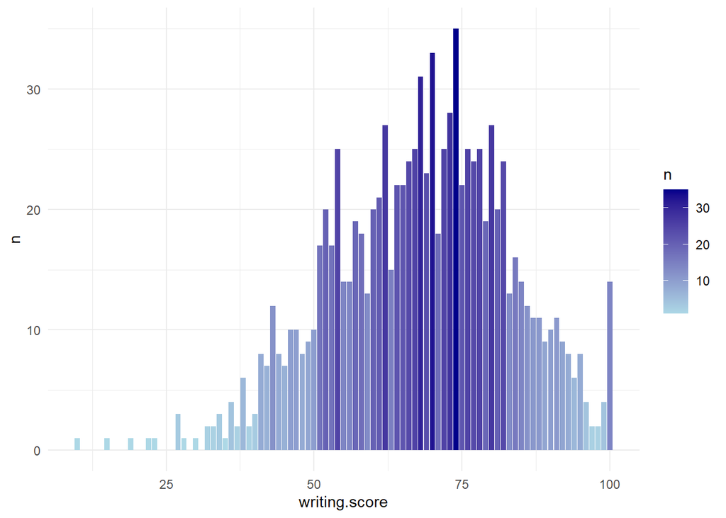

```r
data %>%
  count(writing.score) %>%
  ggplot(aes(x = writing.score, y = n, fill = n)) +
  geom_col() +
  scale_fill_gradient(low = "lightblue", high = "darkblue")
```

Let us observe the writing score first.

How many students passed their writing exam?

```r
df <- data %>%
  mutate(Writing_PassStatus = ifelse(writing.score < passmark, "F", "P"))

df %>%
  count(Writing_PassStatus)
```

```
##   Writing_PassStatus   n
## 1                  F 114
## 2                  P 886
```

We will now see how the parental education effects this exam.

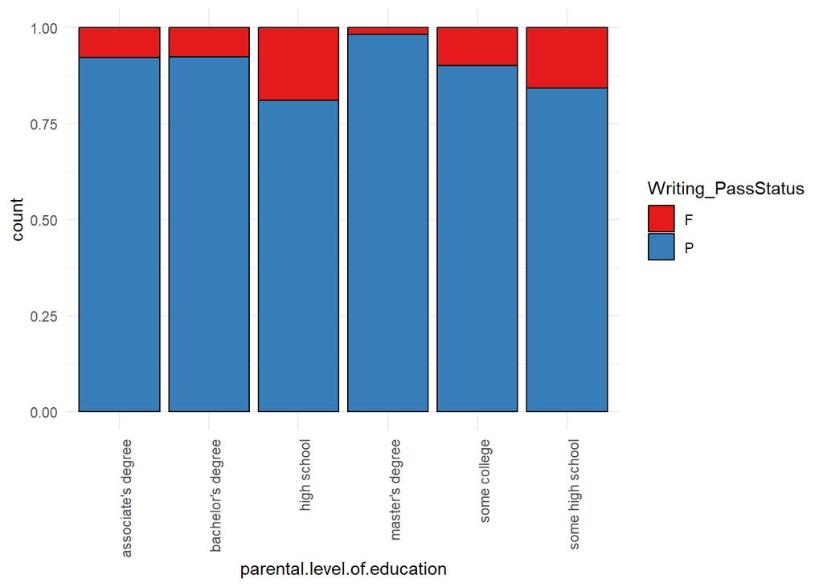

```r
df %>%
  ggplot(aes(x = parental.level.of.education, fill = Writing_PassStatus)) +
  geom_bar(position = "fill", color = "black") +
  scale_fill_brewer(palette = "Set1") +
  theme(axis.text.x = element_text(angle = 90, hjust = 1))
```

As, we can see the best results are held by those students whose parent(s) have a master’s degree, whereas the worst are of those students whose parents went to high school, or some high school.

Now, let’s observe reading score:

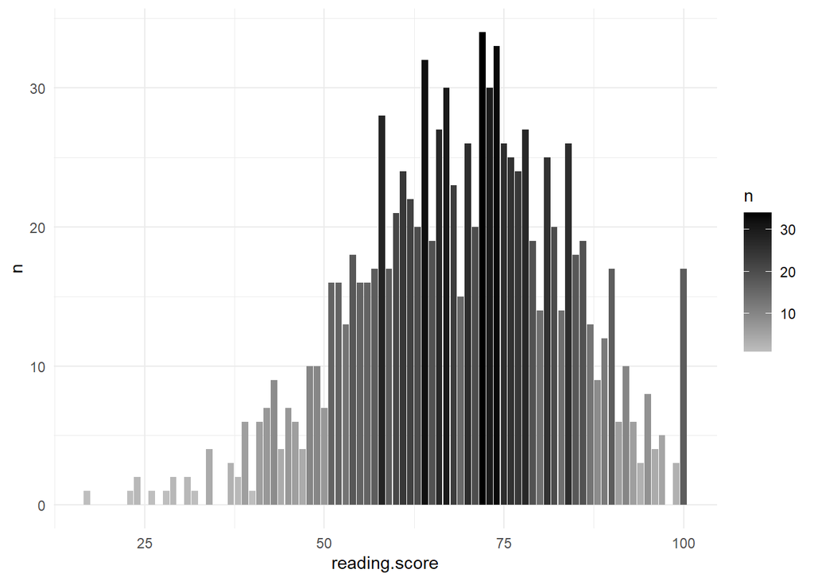

```r
data %>%
  count(reading.score) %>%
  ggplot(aes(x = reading.score, y = n, fill = n)) +
  geom_col() +
  scale_fill_gradient(low = "grey", high = "black")
```

As we can see the amount of students who passed the writing and the reading exam is about the same.

```r
df <- df %>%
  mutate (Reading_PassStatus = c(ifelse(reading.score >= passmark, "P","F") ))
df %>% count(Reading_PassStatus)
```

```
##   Reading_PassStatus   n
## 1                  F  90
## 2                  P 910
```

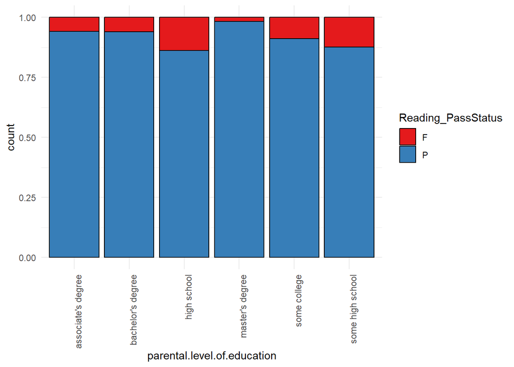

```r
df %>%
  ggplot(aes(x = parental.level.of.education, fill = Reading_PassStatus)) +
  geom_bar(position = "fill", color = "black") +
  scale_fill_brewer(palette = "Set1") +
  theme(axis.text.x = element_text(angle = 90, hjust = 1))
```

The best results are held by students whose parents have a master’s degree and the worst are again in high school, or some high school, so no significant changes.

And finally, let’s observe math:

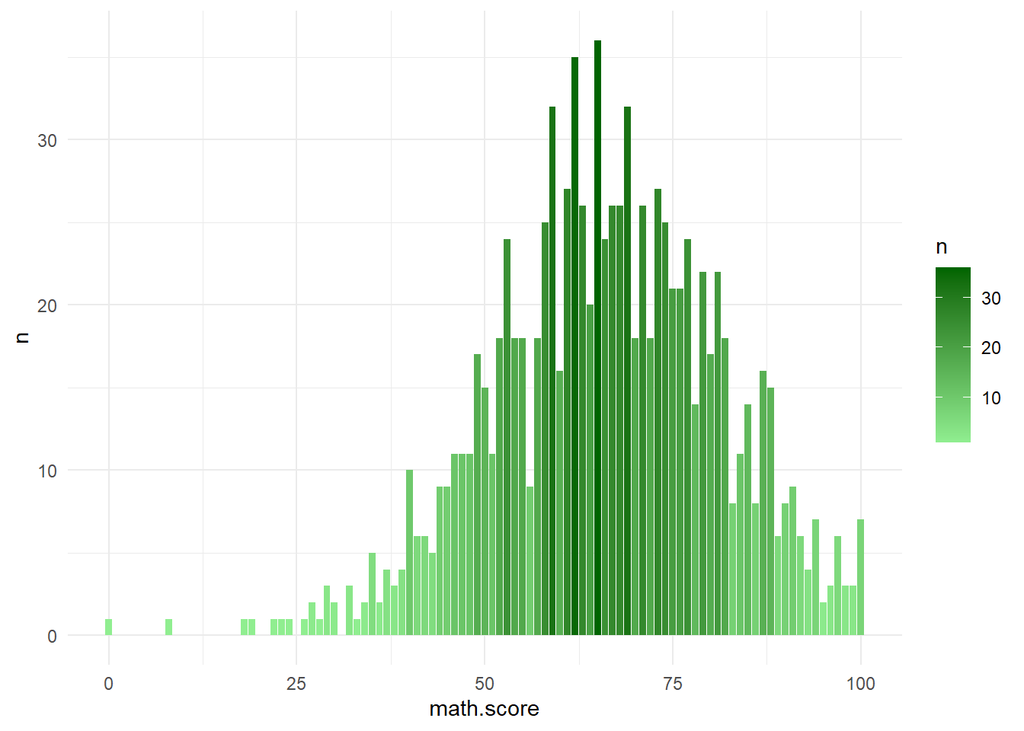

```r
data %>%
  count(math.score)%>%
  ggplot(aes(x = math.score, y = n, fill = n)) +
  geom_col()+
  scale_fill_gradient(low = "lightgreen", high = "darkgreen")
```

By far math seems to have the lowest pass status.

How many students passed math?

```r
df <-  df %>% mutate( Math_PassStatus = c(ifelse( math.score < passmark , "F" , "P" )) )

df %>% count(df$Math_PassStatus)
```

```
##   df$Math_PassStatus   n
## 1                  F 135
## 2                  P 865
```

Observation: - Reading has the highest pass status. - Math has the lowest pass status.

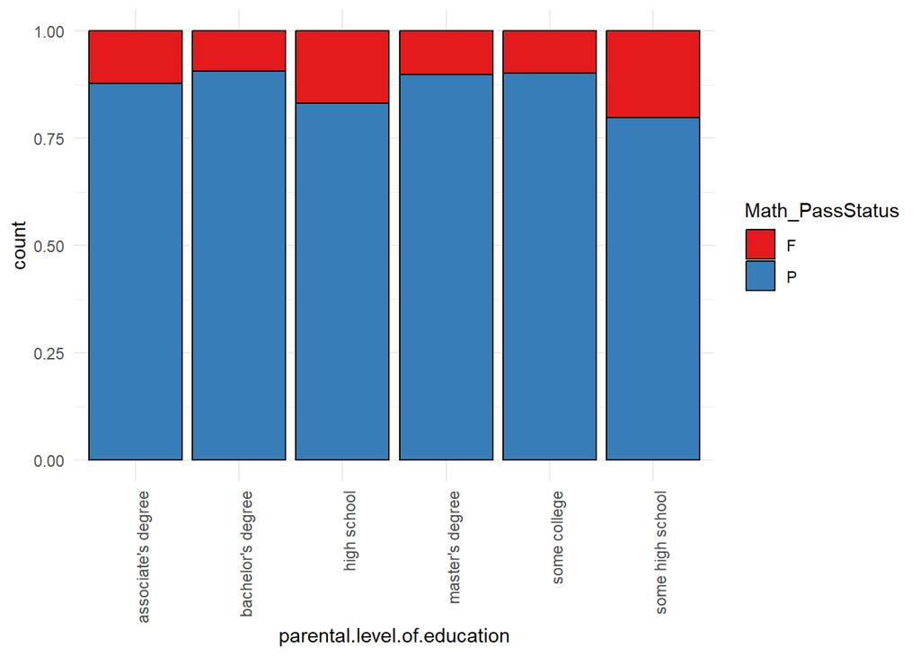

```r
df %>%
  ggplot(aes(x = parental.level.of.education, fill = Math_PassStatus)) +
  geom_bar(position = "fill", color = "black") +
  scale_fill_brewer(palette = "Set1") +
  theme(axis.text.x = element_text(angle = 90, hjust = 1))
```

## Gender Distribution

We will take the exam with the best pass status and the worst pass status and analyse it when it comes to gender density.

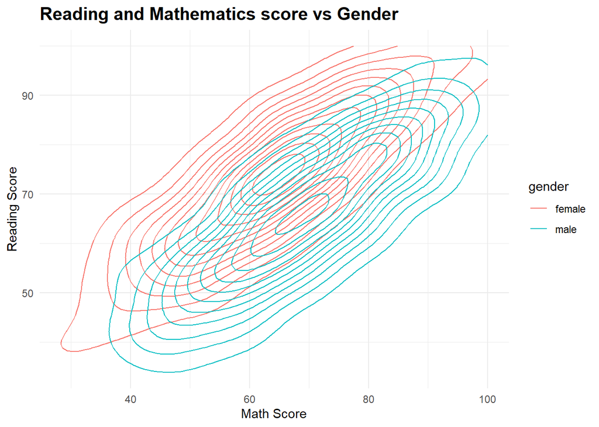

```r
library(ggplot2)
library(ggjoy)

# Set theme and options
theme_set(theme_minimal())
options(repr.plot.width = 30, repr.plot.height = 25)

# Create the jointplot
ggplot(data, aes(x = math.score, y = reading.score, color = gender)) +
  geom_density_2d() +
  labs(x = "Math Score", y = "Reading Score", title = "Reading and Mathematics score vs Gender") +
  theme(plot.title = element_text(size = 15, face = "bold")) +
  guides(fill = guide_legend(title = "Gender")) +
  scale_fill_manual(values = c("Male" = "blue", "Female" = "red"))
```

By this we can see that boys and girls overlap at 70 points for both reading and maths. Bigger number of boys stays between the interval (40,90) and girls are a bit denser for math scores.

When it comes to reading we see that girls performed generally better.

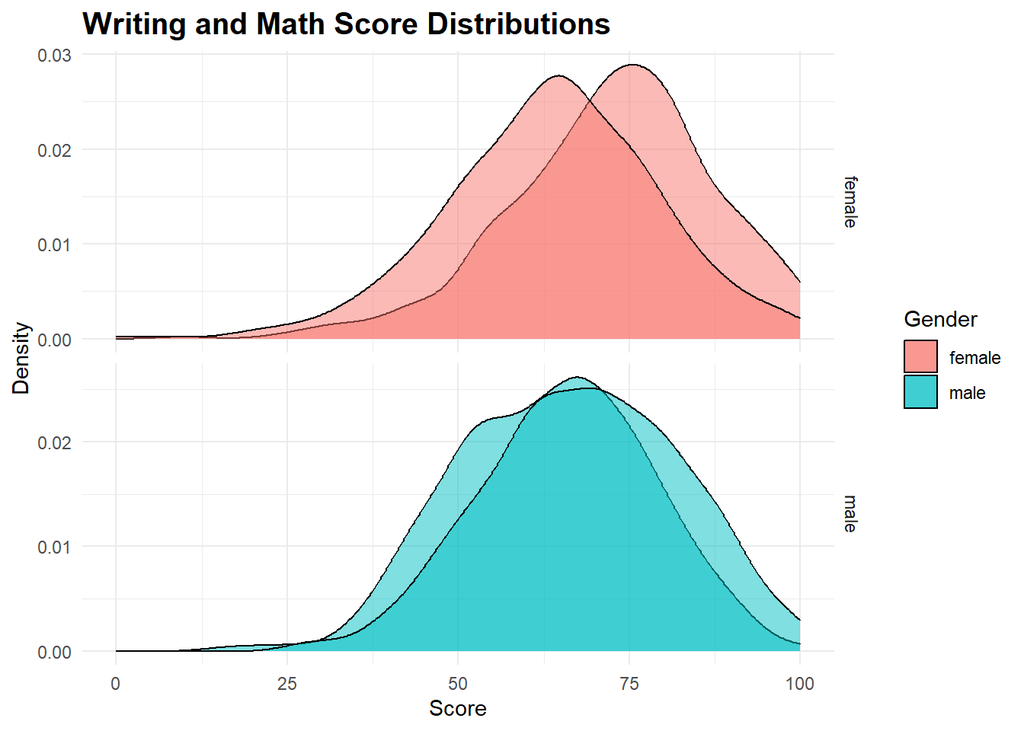

```r
library(ggplot2)

# Set theme and options
theme_set(theme_minimal())
options(repr.plot.width = 8, repr.plot.height = 6)

# Create the joint plot
data %>%
  ggplot() +
  geom_density(aes(x = writing.score, fill = gender), alpha = 0.5) +
  geom_density(aes(x = math.score, fill = gender), alpha = 0.5) +
  labs(x = "Score", y = "Density", title = "Writing and Math Score Distributions") +
  theme_minimal() +
  theme(plot.title = element_text(size = 15, face = "bold")) +
  guides(fill = guide_legend(title = "Gender")) +
  facet_grid(gender ~ ., scales = "free")
```

## Observing variables on Grade

Let’s observe the average results of the students:

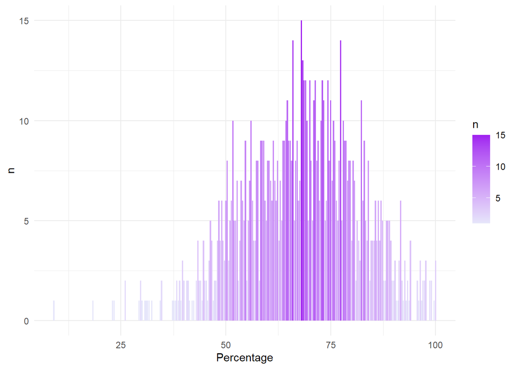

```r
data %>%
  count(Percentage) %>%
  ggplot(aes(x = Percentage, y = n, fill = n)) +
  geom_col() +
  scale_fill_gradient(low = "lavender", high = "purple")
```

And the grades:

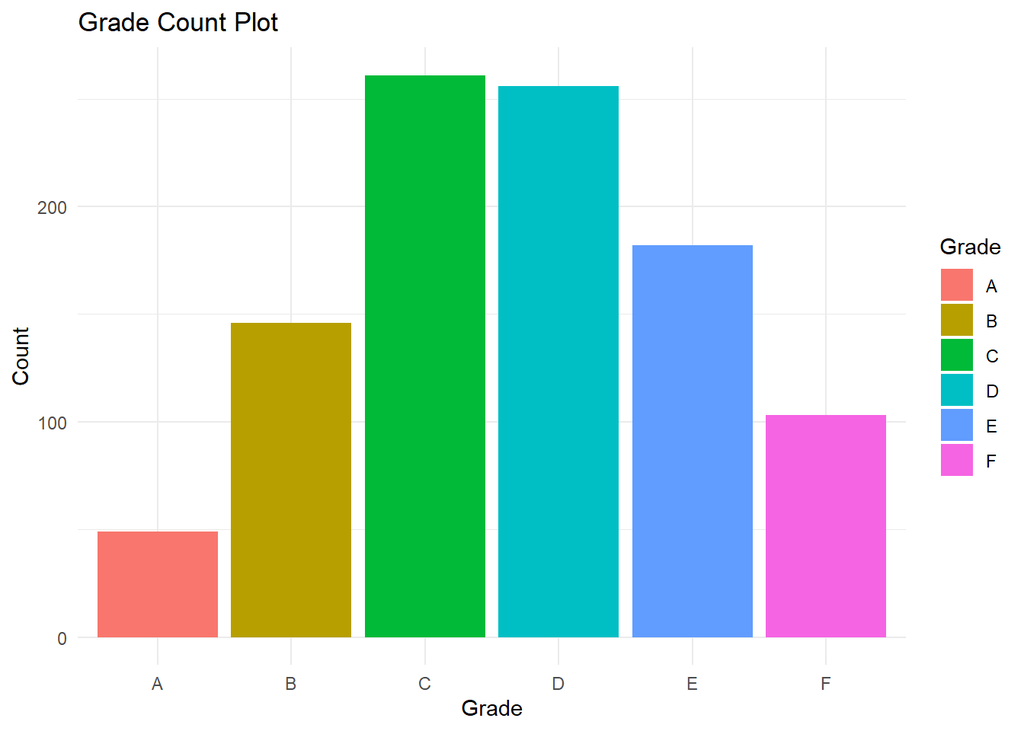

```r
df %>%
  ggplot(aes(x = Grade, fill = Grade)) +
  geom_bar() +
  scale_x_discrete(limits = c('A', 'B', 'C', 'D', 'E', 'F')) +
  labs(x = "Grade", y = "Count", title = "Grade Count Plot") +
  theme_minimal()
```

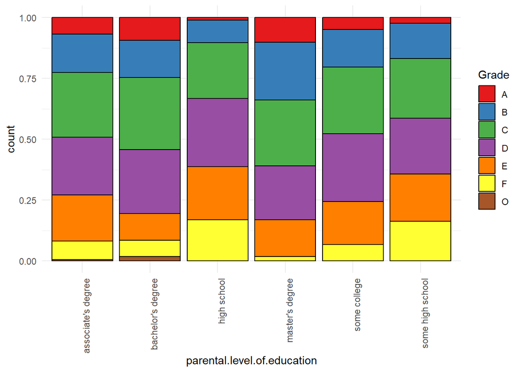

```r
df %>%
  ggplot(aes(x = parental.level.of.education, fill = Grade)) +
  geom_bar(position = "fill", color = "black") +
  scale_fill_brewer(palette = "Set1") +
  theme(axis.text.x = element_text(angle = 90, hjust = 1))
```

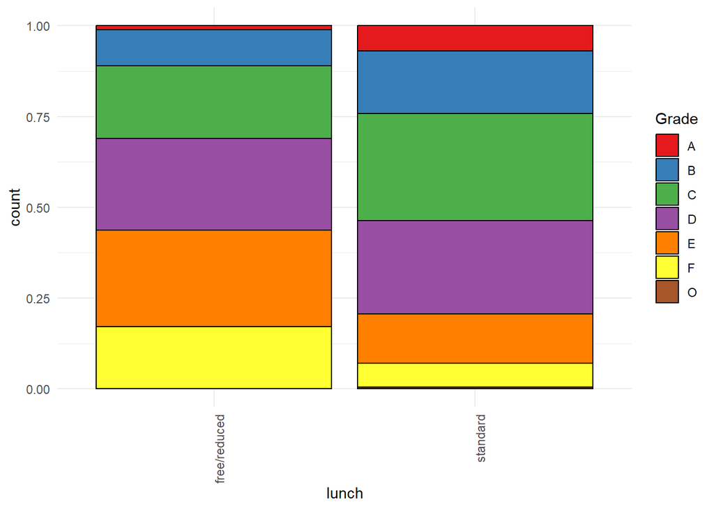

```r
df %>%
  ggplot(aes(x = lunch, fill = Grade)) +
  geom_bar(position = "fill", color = "black") +
  scale_fill_brewer(palette = "Set1") +
  theme(axis.text.x = element_text(angle = 90, hjust = 1))
```

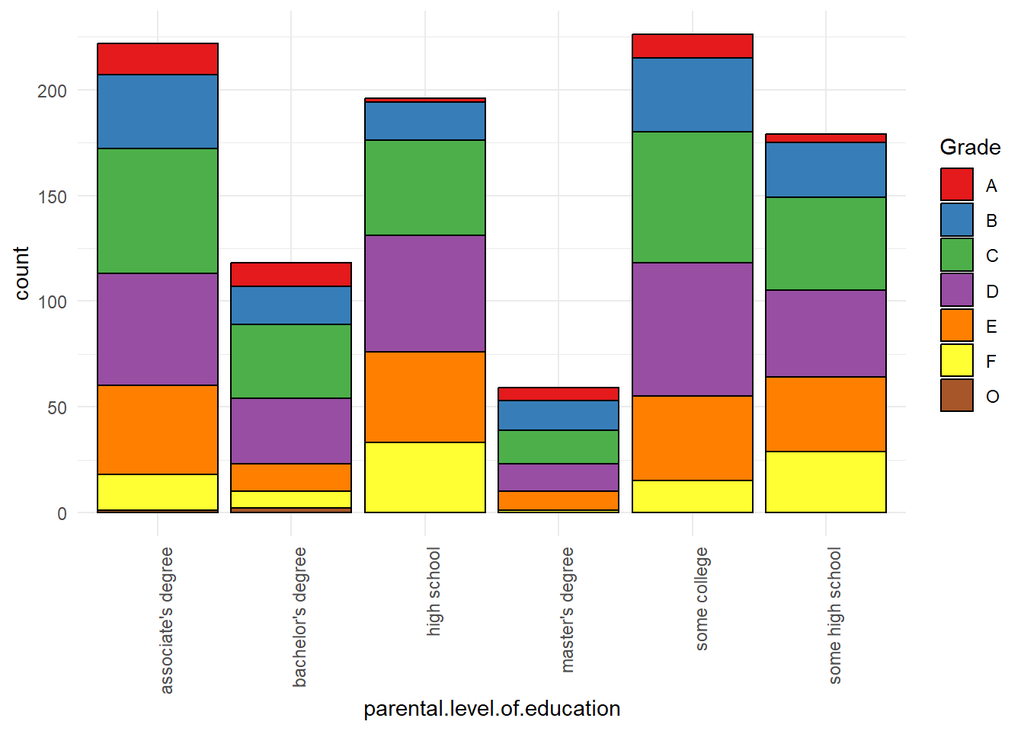

```r
df %>%
  ggplot(aes(x = parental.level.of.education, fill = Grade)) +
  geom_bar(position = "stack", color = "black") +
  scale_fill_brewer(palette = "Set1") +
  theme(axis.text.x = element_text(angle = 90, hjust = 1))
```

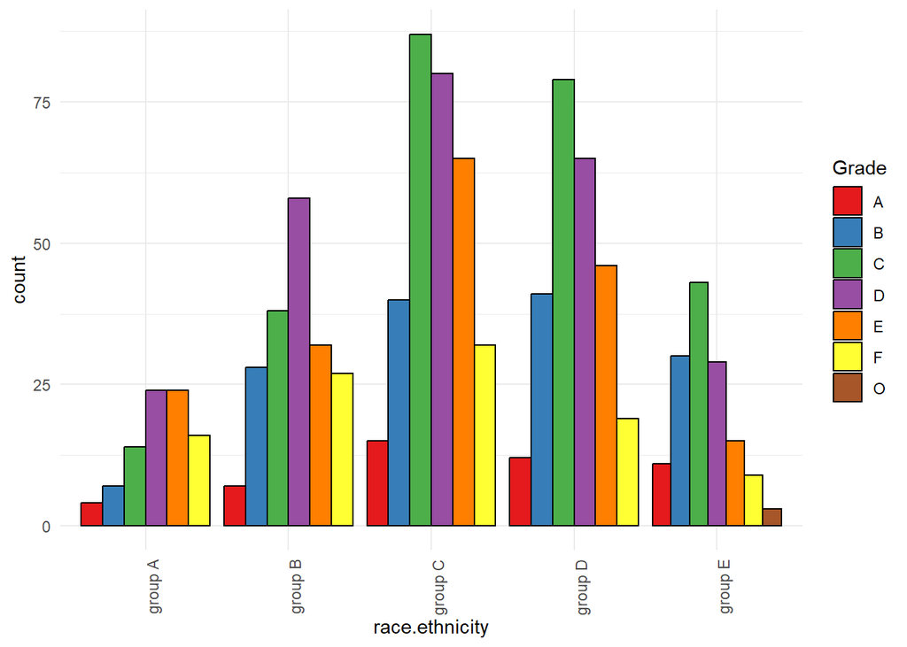

```r
df %>%
  ggplot(aes(x = race.ethnicity, fill = Grade)) +
  geom_bar(position = "dodge", color = "black") +
  scale_fill_brewer(palette = "Set1") +
  theme(axis.text.x = element_text(angle = 90, hjust = 1))
```

```r
data %>% count(race.ethnicity)
```

```
##   race.ethnicity   n
## 1        group A  89
## 2        group B 190
## 3        group C 319
## 4        group D 262
## 5        group E 140
```

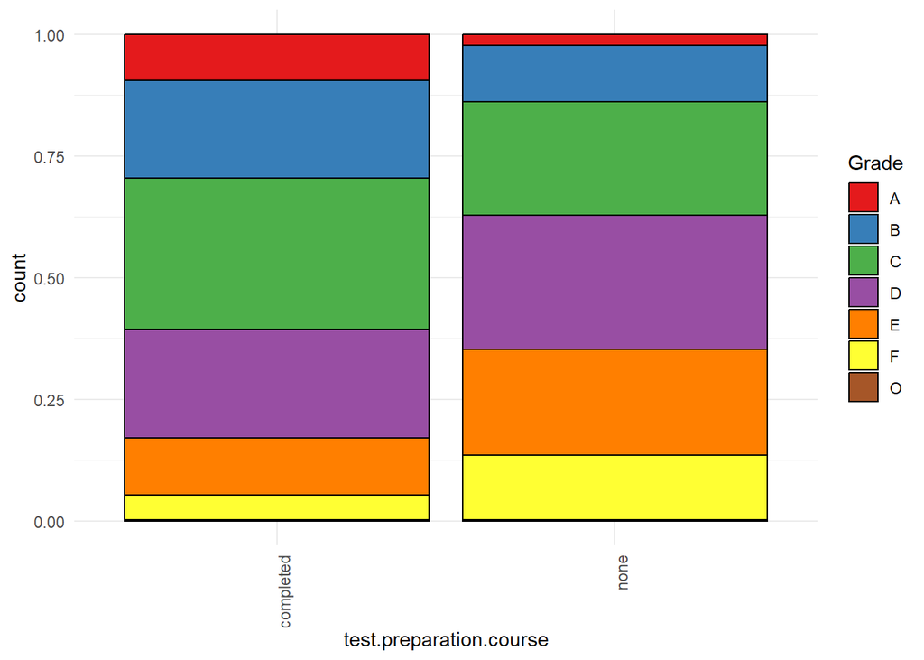

```r
df %>%
  ggplot(aes(x = test.preparation.course, fill = Grade)) +
  geom_bar(position = "fill", color = "black") +
  scale_fill_brewer(palette = "Set1") +
  theme(axis.text.x = element_text(angle = 90, hjust = 1))
```